# BOVIN-Pathway Demo · Database Inspector

20280. `CSNK2A1`

20281. `TAS2R41`

20282. `CIRH1A`

20283. `FZR1`

20284. `MEGF10`

20285. `HBG2`

20286. `HBG1`

20287. `CD2AP`

20288. `SLC2A7`

20289. `SLC47A2`

20290. `ZZEF1`

20291. `PTMS`

20292. `DKKL1`

20293. `SLC2A6`

20294. `KDM5D`

20295. `TP53I13`

20296. `CPS1`

20297. `KDM5B`

20298. `KDM5C`

20299. `CS`

20300. `DAD1L`

20301. `SLC2A4`

20302. `SNORD89`

20303. `AIPL1`

20304. `PDGFA`

20305. `PDGFB`

20306. `SLC2A2`

20307. `STAB2`

20308. `OPN1MW`

20309. `GLUL`

20310. `LONP1`

20311. `DNM1`

20312. `UBE2L3`

20313. `DNM3`

20314. `DNM2`

20315. `TSPAN17`

20316. `SMYD1`

20317. `SNORD85`

20318. `TGFA`

20319. `ICT1`

20320. `SNORD84`

20321. `PREX2`

20322. `ZKSCAN1`

20323. `HCG2P7`

20324. `SDK1`

20325. `RIPPLY2`

20326. `SLC35E3`

20327. `ZPLD1`

20328. `SNORD82`

20329. `MUC21`

20330. `C9orf109`

20331. `ZNF630`

20332. `CNFN`

20333. `LOC440925`

20334. `STK25`

20335. `C9orf100`

20336. `ZNF287`

20337. `C9orf102`

20338. `C9orf103`

20339. `ZNF160`

20340. `ZNF283`

20341. `C9orf106`

20342. `ZNF281`

20343. `AGXT2L1`

20344. `AGXT2L2`

20345. `SLC14A2`

20346. `SLC14A1`

20347. `STRN4`

20348. `OR51V1`

20349. `GYS1`

20350. `GYS2`

20351. `PPAPDC2`

20352. `PLAU`

20353. `KIAA0040`

20354. `CNIH`

20355. `EVPL`

20356. `STT3A`

20357. `PLAT`

20358. `RFXAP`

20359. `STRN3`

20360. `ETV1`

20361. `ETV3`

20362. `ETV2`

20363. `ETV5`

20364. `ETV4`

20365. `ETV7`

20366. `ETV6`

20367. `SDR16C5`

20368. `FAM8A1`

20369. `PCNP`

20370. `BTBD9`

20371. `BTBD8`

20372. `BTBD7`

20373. `BTBD6`

20374. `BTBD1`

20375. `FAM5C`

20376. `BTBD3`

20377. `BTBD2`

20378. `SULT1B1`

20379. `MRPL48`

20380. `RAD23B`

20381. `LUZP2`

20382. `MESDC1`

20383. `RPL29P2`

20384. `SLC6A19`

20385. `HRNR`

20386. `NOM1`

20387. `IKZF5`

20388. `IKZF4`

20389. `IKZF1`

20390. `IKZF3`

20391. `IKZF2`

20392. `C1orf190`

20393. `RHOXF2B`

20394. `SLC24A4`

20395. `TTC18`

20396. `C16orf86`

20397. `C11orf71`

20398. `C11orf70`

20399. `C11orf73`

20400. `STON2`

20401. `C17orf28`

20402. `C11orf74`

20403. `TNFRSF10D`

20404. `IL4I1`

20405. `C1orf194`

20406. `RCOR3`

20407. `ZFYVE27`

20408. `SPATS1`

20409. `PLEKHG2`

20410. `SPATS2`

20411. `SNORD32B`

20412. `PLEKHG3`

20413. `CST11`

20414. `SLC13A2`

20415. `SLC13A3`

20416. `SLC13A4`

20417. `NFIA`

20418. `TCEAL3`

20419. `STON1`

20420. `TCEAL1`

20421. `PLEKHG1`

20422. `TCEAL7`

20423. `TCEAL6`

20424. `TCEAL5`

20425. `TCEAL4`

20426. `TCEAL8`

20427. `RGS16`

20428. `PSPN`

20429. `RGS14`

20430. `IFNA8`

20431. `FAAH`

20432. `RGS13`

20433. `RGS10`

20434. `KNCN`

20435. `ZNF219`

20436. `IFNA2`

20437. `IFNA1`

20438. `SELK`

20439. `IFNA7`

20440. `CCKAR`

20441. `IFNA5`

20442. `IFNA4`

20443. `EMX2OS`

20444. `KDR`

20445. `PHF20L1`

20446. `TIMM22`

20447. `HMX1`

20448. `MYCL1`

20449. `HMX3`

20450. `HMX2`

20451. `ST6GALNAC4`

20452. `SMN2`

20453. `CLEC16A`

20454. `CRYAB`

20455. `MINA`

20456. `CRYAA`

20457. `STOX2`

20458. `RPS25`

20459. `STRA13`

20460. `IGFL2`

20461. `BTN2A3`

20462. `BTN2A2`

20463. `BTN2A1`

20464. `ELF2`

20465. `ELF5`

20466. `ELF4`

20467. `RPS23`

20468. `MRPL21`

20469. `PRPS2`

20470. `CAND2`

20471. `CAND1`

20472. `PRPS1`

20473. `CDR2`

20474. `CDR1`

20475. `RIMBP3`

20476. `BRPF3`

20477. `BRPF1`

20478. `TTLL11`

20479. `TTLL10`

20480. `TTLL13`

20481. `TTLL12`

20482. `LDHD`

20483. `GMPR2`

20484. `AMELY`

20485. `FOXD4`

20486. `LDHB`

20487. `LDHC`

20488. `DNASE2B`

20489. `ODF2L`

20490. `FOXD2`

20491. `ACAP1`

20492. `ACAP2`

20493. `ACAP3`

20494. `LUZP4`

20495. `OR10J5`

20496. `LUZP6`

20497. `C1orf198`

20498. `CFL2`

20499. `CFL1`

20500. `OR10J3`

20501. `C8orf83`

20502. `C1orf192`

20503. `PLAA`

20504. `C8orf80`

20505. `C8orf86`

20506. `C8orf85`

20507. `C8orf84`

20508. `NFIC`

20509. `NFIB`

20510. `H1FOO`

20511. `NFIX`

20512. `PLEKHG6`

20513. `PLEKHG7`

20514. `PLEKHG4`

20515. `PLEKHG5`

20516. `SLC7A14`

20517. `SELE`

20518. `SLC7A10`

20519. `PLA2G2C`

20520. `METTL11A`

20521. `TULP2`

20522. `NPY5R`

20523. `GNGT2`

20524. `GNGT1`

20525. `TULP3`

20526. `PTRF`

20527. `BCL6B`

20528. `GSTK1`

20529. `SELP`

20530. `SELS`

### (b) head(10)

```python
representative_l = [g for g in SIGNATURE + EXTRA if g in expr_l.columns]
expr_l[representative_l].head(10).round(3)
```

| gene sample | CALR | HMGB1 | HSPA1A | HSP90AA1 | CD47 | CD24 | CD8A | PDCD1 | CD274 | IFNG |
| --- | --- | --- | --- | --- | --- | --- | --- | --- | --- | --- |
| TCGA-69-7978-01 | 14.586 | 11.579 | 14.782 | 14.449 | 12.307 | 9.403 | 9.773 | 8.415 | 9.467 | 5.627 |
| TCGA-62-8399-01 | 13.890 | 11.403 | 12.974 | 13.476 | 12.359 | 13.703 | 7.858 | 4.913 | 6.428 | 1.329 |
| TCGA-78-7539-01 | 14.369 | 11.609 | 13.322 | 14.173 | 12.176 | 12.686 | 9.446 | 7.145 | 6.116 | 4.618 |
| TCGA-50-5931-11 | 13.950 | 12.296 | 13.154 | 13.740 | 13.128 | 11.151 | 7.911 | 3.963 | 7.724 | 0.000 |
| TCGA-73-4658-01 | 14.586 | 11.838 | 13.083 | 14.112 | 12.088 | 11.724 | 8.466 | 6.513 | 9.062 | 3.645 |
| TCGA-44-6775-01 | 14.384 | 11.856 | 12.382 | 13.956 | 12.295 | 13.541 | 7.194 | 5.299 | 6.290 | 1.330 |
| TCGA-44-2655-01 | 14.856 | 12.576 | 13.777 | 15.069 | 13.003 | 13.967 | 7.092 | 5.105 | 4.932 | 1.353 |
| TCGA-44-3398-01 | 14.654 | 12.832 | 11.077 | 13.618 | 12.454 | 12.715 | 8.152 | 4.973 | 7.752 | 2.401 |
| TCGA-62-8397-01 | 14.327 | 11.440 | 13.212 | 14.181 | 11.256 | 12.658 | 5.662 | 4.320 | 5.112 | 0.000 |
| TCGA-53-A4EZ-01 | 13.889 | 12.822 | 13.893 | 14.622 | 10.511 | 13.378 | 7.356 | 5.799 | 4.598 | 1.569 |

### (c) 关联性 — 6 个 ICD 签名基因的两两 Pearson

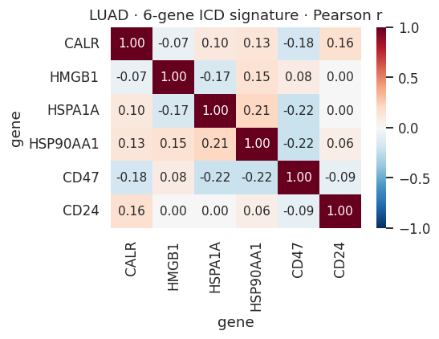

```python
fig, ax = plt.subplots(figsize=(5.2, 4))
sns.heatmap(expr_l[SIGNATURE].corr(), annot=True, fmt=".2f", cmap="RdBu_r",
            center=0, vmin=-1, vmax=1, ax=ax, annot_kws={"size": 10})
ax.set_title("LUAD · 6-gene ICD signature · Pearson r")
plt.tight_layout(); plt.show()
```

### (d) 分布

[output not shown]

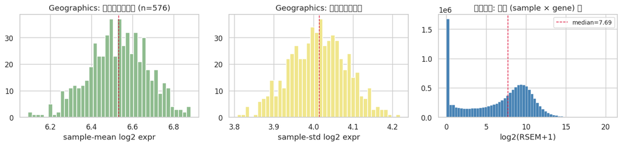

```python
fig, axes = plt.subplots(1, 3, figsize=(13.5, 3.3))
per_sample_mean = expr_l.mean(axis=1)
axes[0].hist(per_sample_mean, bins=40, color="darkseagreen", edgecolor="white")
axes[0].axvline(per_sample_mean.median(), color="crimson", lw=1, ls="--")
axes[0].set_title(f"Geographics: 每个样本的均值 (n={len(per_sample_mean)})")
axes[0].set_xlabel("sample-mean log2 expr")
per_sample_std = expr_l.std(axis=1)
axes[1].hist(per_sample_std, bins=40, color="khaki", edgecolor="white")
axes[1].axvline(per_sample_std.median(), color="crimson", lw=1, ls="--")
axes[1].set_title("Geographics: 每个样本的方差")
axes[1].set_xlabel("sample-std log2 expr")
overall_value_hist(expr_l.values, "整体分布: 所有 (sample × gene) 值", ax=axes[2])
axes[2].set_xlabel("log2(RSEM+1)")
plt.tight_layout(); plt.show()
```

## §1.5 · TCGA-LUAD 临床矩阵

```python
clin_l, clin_l_path = _load_clinical(RAW_LUAD, "LUAD")
```

### (a) shape · headers · 大小

```python
anatomy(clin_l, clin_l_path, "LUAD clinical matrix", col_sample=10)
annot_l = annotate_columns(clin_l, CLINICAL_DICT)
print()
print("Columns per category:")
print(annot_l["category"].value_counts().to_string())
```

```
═══ LUAD clinical matrix ═══
shape      : 706 rows  ×  147 columns
file size  : 693.5 KB   on disk
memory     : 4.37 MB   in pandas
dtypes     : {dtype('O'): 117, dtype('float64'): 30}
```

**columns (147) — click to expand full list**

1. `ABSOLUTE_Ploidy`

2. `ABSOLUTE_Purity`

3. `AKT1`

4. `ALK_translocation`

5. `BRAF`

6. `CBL`

7. `CTNNB1`

8. `Canonical_mut_in_KRAS_EGFR_ALK`

9. `Cnncl_mt_n_KRAS_EGFR_ALK_RET_ROS1_BRAF_ERBB2_HRAS_NRAS_AKT1_MAP2`

10. `EGFR`

11. `ERBB2`

12. `ERBB4`

13. `Estimated_allele_fraction_of_a_clonal_varnt_prsnt_t_1_cpy_pr_cll`

14. `Expression_Subtype`

15. `HRAS`

16. `KRAS`

17. `MAP2K1`

18. `MET`

19. `NRAS`

20. `PIK3CA`

21. `PTPN11`

22. `Pathology`

23. `Pathology_Updated`

24. `RET_translocation`

25. `ROS1_translocation`

26. `STK11`

27. `WGS_as_of_20120731_0_no_1_yes`

28. `_INTEGRATION`

29. `_PANCAN_CNA_PANCAN_K8`

30. `_PANCAN_Cluster_Cluster_PANCAN`

31. `_PANCAN_DNAMethyl_LUAD`

32. `_PANCAN_DNAMethyl_PANCAN`

33. `_PANCAN_RPPA_PANCAN_K8`

34. `_PANCAN_UNC_RNAseq_PANCAN_K16`

35. `_PANCAN_miRNA_PANCAN`

36. `_PANCAN_mirna_LUAD`

37. `_PANCAN_mutation_PANCAN`

38. `_PATIENT`

39. `_cohort`

40. `_primary_disease`

41. `_primary_site`

42. `additional_pharmaceutical_therapy`

43. `additional_radiation_therapy`

44. `additional_surgery_locoregional_procedure`

45. `additional_surgery_metastatic_procedure`

46. `age_at_initial_pathologic_diagnosis`

47. `anatomic_neoplasm_subdivision`

48. `anatomic_neoplasm_subdivision_other`

49. `bcr_followup_barcode`

50. `bcr_patient_barcode`

51. `bcr_sample_barcode`

52. `days_to_additional_surgery_locoregional_procedure`

53. `days_to_additional_surgery_metastatic_procedure`

54. `days_to_birth`

55. `days_to_collection`

56. `days_to_death`

57. `days_to_initial_pathologic_diagnosis`

58. `days_to_last_followup`

59. `days_to_new_tumor_event_after_initial_treatment`

60. `disease_code`

61. `dlco_predictive_percent`

62. `eastern_cancer_oncology_group`

63. `egfr_mutation_performed`

64. `egfr_mutation_result`

65. `eml4_alk_translocation_method`

66. `eml4_alk_translocation_performed`

67. `followup_case_report_form_submission_reason`

68. `followup_treatment_success`

69. `form_completion_date`

70. `gender`

71. `histological_type`

72. `history_of_neoadjuvant_treatment`

73. `icd_10`

74. `icd_o_3_histology`

75. `icd_o_3_site`

76. `informed_consent_verified`

77. `initial_weight`

78. `intermediate_dimension`

79. `is_ffpe`

80. `karnofsky_performance_score`

81. `kras_gene_analysis_performed`

82. `kras_mutation_found`

83. `kras_mutation_result`

84. `location_in_lung_parenchyma`

85. `longest_dimension`

86. `lost_follow_up`

87. `new_neoplasm_event_type`

88. `new_tumor_event_after_initial_treatment`

89. `number_pack_years_smoked`

90. `oct_embedded`

91. `other_dx`

92. `pathologic_M`

93. `pathologic_N`

94. `pathologic_T`

95. `pathologic_stage`

96. `pathology_report_file_name`

97. `patient_id`

98. `performance_status_scale_timing`

99. `person_neoplasm_cancer_status`

100. `post_bronchodilator_fev1_fvc_percent`

101. `post_bronchodilator_fev1_percent`

102. `pre_bronchodilator_fev1_fvc_percent`

103. `pre_bronchodilator_fev1_percent`

104. `primary_therapy_outcome_success`

105. `progression_determined_by`

106. `project_code`

107. `pulmonary_function_test_performed`

108. `radiation_therapy`

109. `residual_tumor`

110. `sample_type`

111. `sample_type_id`

112. `shortest_dimension`

113. `stopped_smoking_year`

114. `system_version`

115. `targeted_molecular_therapy`

116. `tissue_prospective_collection_indicator`

117. `tissue_retrospective_collection_indicator`

118. `tissue_source_site`

119. `tobacco_smoking_history`

120. `tobacco_smoking_history_indicator`

121. `tumor_tissue_site`

122. `vial_number`

123. `vital_status`

124. `year_of_initial_pathologic_diagnosis`

125. `year_of_tobacco_smoking_onset`

126. `_GENOMIC_ID_TCGA_LUAD_mutation`

127. `_GENOMIC_ID_TCGA_LUAD_mutation_curated_broad_gene`

128. `_GENOMIC_ID_TCGA_LUAD_PDMarray`

129. `_GENOMIC_ID_TCGA_LUAD_exp_HiSeqV2`

130. `_GENOMIC_ID_TCGA_LUAD_G4502A_07_3`

131. `_GENOMIC_ID_TCGA_LUAD_hMethyl27`

132. `_GENOMIC_ID_data/public/TCGA/LUAD/miRNA_GA_gene`

133. `_GENOMIC_ID_TCGA_LUAD_gistic2`

134. `_GENOMIC_ID_TCGA_LUAD_hMethyl450`

135. `_GENOMIC_ID_TCGA_LUAD_PDMRNAseqCNV`

136. `_GENOMIC_ID_TCGA_LUAD_gistic2thd`

137. `_GENOMIC_ID_TCGA_LUAD_PDMarrayCNV`

138. `_GENOMIC_ID_TCGA_LUAD_exp_HiSeqV2_exon`

139. `_GENOMIC_ID_TCGA_LUAD_miRNA_HiSeq`

140. `_GENOMIC_ID_TCGA_LUAD_RPPA_RBN`

141. `_GENOMIC_ID_TCGA_LUAD_exp_HiSeqV2_PANCAN`

142. `_GENOMIC_ID_TCGA_LUAD_PDMRNAseq`

143. `_GENOMIC_ID_TCGA_LUAD_RPPA`

144. `_GENOMIC_ID_TCGA_LUAD_exp_HiSeqV2_percentile`

145. `_GENOMIC_ID_TCGA_LUAD_mutation_broad_gene`

146. `_GENOMIC_ID_data/public/TCGA/LUAD/miRNA_HiSeq_gene`

147. `_GENOMIC_ID_TCGA_LUAD_miRNA_GA`

```
Columns per category:
category
⚠ undocumented      55
xena_omics_flags    22
specimen            21
outcome             12
staging             10
pancan               9
xena_meta            5
treatment            4
admin                4
demographics         3
biology              2
```

### (b) head(10)

```python
# LUAD 同样用关键 7 列做预览
key_l = [c for c in KEY_CLIN if c in clin_l.columns]
clin_l[key_l].head(10)
```

| sample | gender | age_at_initial_pathologic_diagnosis | pathologic_stage | vital_status | tissue_source_site |
| --- | --- | --- | --- | --- | --- |
| TCGA-05-4244-01 | MALE | 70.0 | Stage IV | LIVING | 05 |
| TCGA-05-4249-01 | MALE | 67.0 | Stage IB | LIVING | 05 |
| TCGA-05-4250-01 | FEMALE | 79.0 | Stage IIIA | DECEASED | 05 |
| TCGA-05-4382-01 | MALE | 68.0 | Stage IB | LIVING | 05 |
| TCGA-05-4384-01 | MALE | 66.0 | Stage IIIA | LIVING | 05 |
| TCGA-05-4389-01 | MALE | 70.0 | Stage IA | LIVING | 05 |
| TCGA-05-4390-01 | FEMALE | 58.0 | Stage IB | LIVING | 05 |
| TCGA-05-4395-01 | MALE | 76.0 | Stage IIIB | DECEASED | 05 |
| TCGA-05-4396-01 | MALE | 76.0 | Stage IIIB | DECEASED | 05 |
| TCGA-05-4397-01 | MALE | 65.0 | Stage IIB | DECEASED | 05 |

### (c) 关联性 — 关键字段交叉表 + 数值 Pearson

```python
if "pathologic_stage" in clin_l.columns:
    print("gender × AJCC stage:")
    print(pd.crosstab(clin_l["gender"], clin_l["pathologic_stage"], dropna=False, margins=True).to_string())
print()
print("gender × vital_status:")
print(pd.crosstab(clin_l["gender"], clin_l["vital_status"], dropna=False, margins=True).to_string())
```

```
gender × AJCC stage:
pathologic_stage  Stage I  Stage IA  Stage IB  Stage II  Stage IIA  Stage IIB  Stage IIIA  Stage IIIB  Stage IV  [Discrepancy]  NaN    All
gender
FEMALE                  5       102        94         1         26         44          53           6        15              4    0  350.0
MALE                    0        63        79         0         35         45          42           6        16              5    1  292.0
NaN                     0         0         0         0          0          0           0           0         0              0   64    NaN
All                     5       165       173         1         61         89          95          12        31              9    0  706.0

gender × vital_status:
vital_status  DECEASED  LIVING  NaN    All
gender
FEMALE             130     220    0  350.0
MALE               114     178    0  292.0
NaN                  0       0   64    NaN
All                244     398    0  706.0
```

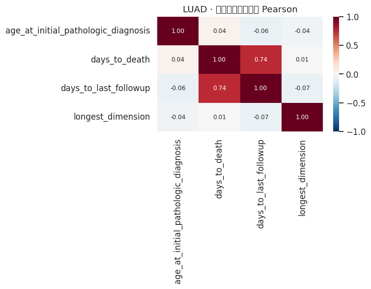

```python
num_l = [c for c in num_fields if c in clin_l.columns]
num_df_l = clin_l[num_l].apply(pd.to_numeric, errors="coerce")
fig, ax = plt.subplots(figsize=(7, 5.5))
sns.heatmap(num_df_l.corr(), annot=True, fmt=".2f", cmap="RdBu_r", center=0,
            vmin=-1, vmax=1, ax=ax, annot_kws={"size": 8})
ax.set_title("LUAD · 关键数值临床字段 Pearson")
plt.tight_layout(); plt.show()
```

### (d) 分布

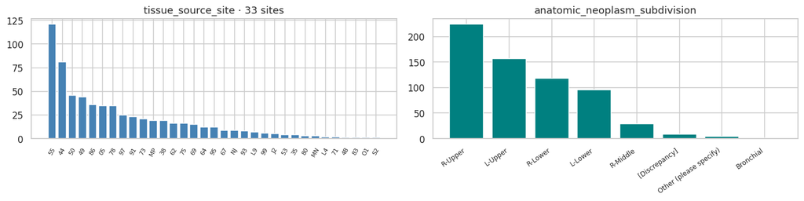

```python
fig, axes = plt.subplots(1, 2, figsize=(13.5, 3.5))
if "tissue_source_site" in clin_l.columns:
    vc = clin_l["tissue_source_site"].value_counts()
    axes[0].bar(vc.index, vc.values, color="steelblue")
    axes[0].set_title(f"tissue_source_site · {len(vc)} sites")
    axes[0].tick_params(axis="x", rotation=60, labelsize=7)
if "anatomic_neoplasm_subdivision" in clin_l.columns:
    vc = clin_l["anatomic_neoplasm_subdivision"].value_counts()
    axes[1].bar(range(len(vc)), vc.values, color="teal")
    axes[1].set_xticks(range(len(vc)))
    axes[1].set_xticklabels(vc.index, rotation=35, ha="right", fontsize=8)
    axes[1].set_title("anatomic_neoplasm_subdivision")
plt.tight_layout(); plt.show()
```

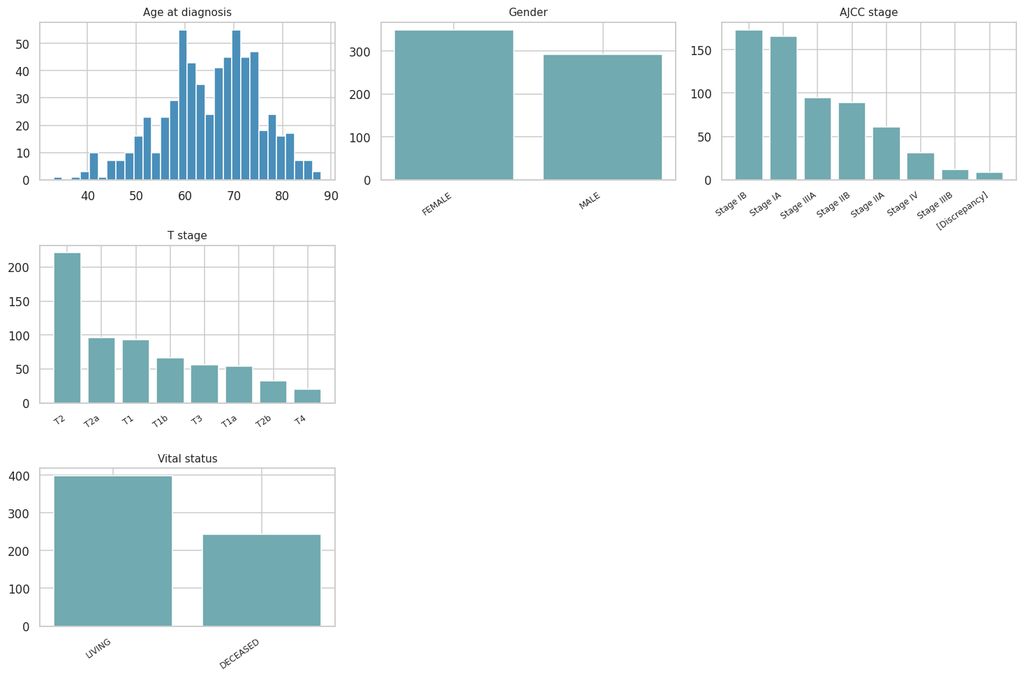

```python
fig, axes = plt.subplots(3, 3, figsize=(13.5, 9))
for ax, (col, kind, title) in zip(axes.ravel(), plots):
    if col not in clin_l.columns:
        ax.set_visible(False); continue
    if kind == "hist":
        vals = pd.to_numeric(clin_l[col], errors="coerce").dropna()
        ax.hist(vals, bins=30, color="#4a8fba", edgecolor="white")
    else:
        vc = clin_l[col].value_counts().head(8)
        ax.bar(range(len(vc)), vc.values, color="#71aab0")
        ax.set_xticks(range(len(vc)))
        ax.set_xticklabels(vc.index, rotation=35, ha="right", fontsize=8)
    ax.set_title(title, fontsize=10)
plt.tight_layout(); plt.show()
```

## §1.6 · TCGA-LUAD 生存文件

```python
surv_l, surv_l_path = _load_survival(RAW_LUAD)
```

### (a) shape · headers · 大小

```python
anatomy(surv_l, surv_l_path, "LUAD survival file", show_all_cols=True)
```

```
═══ LUAD survival file ═══
shape      : 641 rows  ×  10 columns
file size  : 33.2 KB   on disk
memory     : 0.13 MB   in pandas
dtypes     : {dtype('float64'): 7, dtype('int64'): 2, dtype('O'): 1}
```

**columns (10) — click to expand full list**

1. `_PATIENT`

2. `OS`

3. `OS.time`

4. `DSS`

5. `DSS.time`

6. `DFI`

7. `DFI.time`

8. `PFI`

9. `PFI.time`

10. `Redaction`

### (b) head(10)

```python
surv_l.head(10)
```

| sample | _PATIENT | OS | OS.time | DSS | DSS.time | DFI | DFI.time | PFI | PFI.time | Redaction |
| --- | --- | --- | --- | --- | --- | --- | --- | --- | --- | --- |
| TCGA-05-4244-01 | TCGA-05-4244 | 0 | 0.0 | 0.0 | 0.0 | NaN | NaN | 0 | 0.0 | NaN |
| TCGA-05-4249-01 | TCGA-05-4249 | 0 | 1523.0 | 0.0 | 1523.0 | NaN | NaN | 0 | 1523.0 | NaN |
| TCGA-05-4250-01 | TCGA-05-4250 | 1 | 121.0 | NaN | 121.0 | NaN | NaN | 0 | 121.0 | NaN |
| TCGA-05-4382-01 | TCGA-05-4382 | 0 | 607.0 | 0.0 | 607.0 | 1.0 | 334.0 | 1 | 334.0 | NaN |
| TCGA-05-4384-01 | TCGA-05-4384 | 0 | 426.0 | 0.0 | 426.0 | NaN | NaN | 1 | 183.0 | NaN |
| TCGA-05-4389-01 | TCGA-05-4389 | 0 | 1369.0 | 0.0 | 1369.0 | NaN | NaN | 0 | 1369.0 | NaN |
| TCGA-05-4390-01 | TCGA-05-4390 | 0 | 1126.0 | 0.0 | 1126.0 | NaN | NaN | 1 | 395.0 | NaN |
| TCGA-05-4395-01 | TCGA-05-4395 | 1 | 0.0 | 0.0 | 0.0 | NaN | NaN | 0 | 0.0 | NaN |
| TCGA-05-4396-01 | TCGA-05-4396 | 1 | 303.0 | NaN | 303.0 | NaN | NaN | 0 | 303.0 | NaN |
| TCGA-05-4397-01 | TCGA-05-4397 | 1 | 731.0 | NaN | 731.0 | NaN | NaN | 0 | 731.0 | NaN |

### (c) 关联性

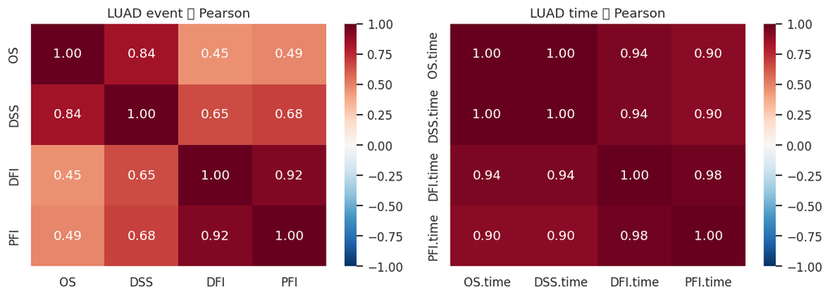

```python
event_cols_l = [c for c in ["OS", "DSS", "DFI", "PFI"] if c in surv_l.columns]
time_cols_l  = [f"{c}.time" for c in event_cols_l if f"{c}.time" in surv_l.columns]
fig, axes = plt.subplots(1, 2, figsize=(11, 4))
sns.heatmap(surv_l[event_cols_l].astype(float).corr(), annot=True, fmt=".2f",
            cmap="RdBu_r", center=0, vmin=-1, vmax=1, ax=axes[0])
axes[0].set_title("LUAD event 列 Pearson")
sns.heatmap(surv_l[time_cols_l].corr(), annot=True, fmt=".2f",
            cmap="RdBu_r", center=0, vmin=-1, vmax=1, ax=axes[1])
axes[1].set_title("LUAD time 列 Pearson")
plt.tight_layout(); plt.show()
```

### (d) 分布

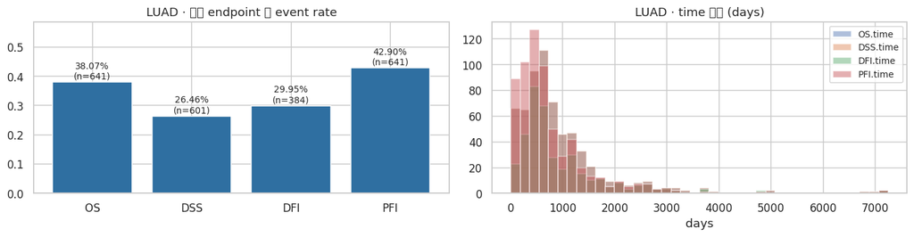

```python
fig, axes = plt.subplots(1, 2, figsize=(13, 3.5))
rates_l = []
for ep in event_cols_l:
    s = surv_l[ep].dropna()
    rates_l.append({"endpoint": ep, "n": len(s), "event_rate": float(s.mean())})
rdf_l = pd.DataFrame(rates_l)
axes[0].bar(rdf_l["endpoint"], rdf_l["event_rate"], color="#2f6fa1")
for i, r in enumerate(rdf_l.itertuples()):
    axes[0].text(i, r.event_rate + 0.01, f"{r.event_rate:.2%}\n(n={r.n})",
                 ha="center", fontsize=9)
axes[0].set_ylim(0, max(rdf_l["event_rate"])*1.25 + 0.05)
axes[0].set_title("LUAD · 每个 endpoint 的 event rate")
for col in time_cols_l:
    axes[1].hist(surv_l[col].dropna(), bins=40, alpha=0.45, label=col)
axes[1].legend(fontsize=9)
axes[1].set_title("LUAD · time 分布 (days)")
axes[1].set_xlabel("days")
plt.tight_layout(); plt.show()
```

## §1.7 · BOVIN-Pathway 图

这是一张自制的异质图（heterogeneous graph），把 BOVIN 论文的生物学因果链结构化成 82 节点 / 99 边。节点属性有 8 个字段，边属性有 7 个。

```python
with open(GRAPH_JSON) as f:
    graph = json.load(f)
nodes = pd.DataFrame(graph["nodes"])
edges = pd.DataFrame(graph["edges"])
```

### (a) shape · headers · 大小

```python
print("═══ BOVIN-Pathway graph ═══")
print(f"file size   : {file_size_kb(GRAPH_JSON)}")
print(f"version     : {graph.get('version')}")
print(f"modules     : {len(graph.get('modules', []))}")
print(f"nodes       : {len(nodes):,} rows × {nodes.shape[1]} cols")
print(f"edges       : {len(edges):,} rows × {edges.shape[1]} cols")

# Full column lists in dropdowns — same UX as §1.1-§1.6
for label, frame in [("nodes", nodes), ("edges", edges)]:
    cols = list(frame.columns)
    items = "".join(
        f"<li style='padding:1px 6px;'><code>{c}</code></li>" for c in cols
    )
    display(HTML(f'''
<details open style="margin:4px 0 10px 0; border:1px solid #e1e4e8;
                     border-radius:6px; padding:6px 10px; background:#fafbfc;">
  <summary style="cursor:pointer; font-weight:600; color:#24292e; user-select:none;">
    {label} · columns ({len(cols)}) — click to expand full list
  </summary>
  <ol style="column-count:3; column-gap:18px;
             font-family: ui-monospace, 'SF Mono', Consolas, monospace;
             font-size:11.5px; line-height:1.45;
             margin:8px 0 2px 20px; padding:0; color:#24292e;">
    {items}
  </ol>
</details>
'''))
```

```
═══ BOVIN-Pathway graph ═══
file size   : 39.6 KB
version     : v0.1
modules     : 11
nodes       : 82 rows × 8 cols
edges       : 99 rows × 7 cols
```

**nodes · columns (8) — click to expand full list**

1. `id`

2. `symbol`

3. `name`

4. `type`

5. `side`

6. `observable`

7. `module`

8. `refs`

**edges · columns (7) — click to expand full list**

1. `source`

2. `relation`

3. `target`

4. `direction`

5. `module_from`

6. `module_to`

7. `evidence`

### (b) head(10) — nodes 和 edges 各前 10 行

```python
print("── nodes.head(10) ──")
print(nodes.head(10).to_string(max_colwidth=40))
```

```
── nodes.head(10) ──
         id       symbol                                     name        type     side  observable module                                     refs
0        ha           HA  Hemagglutinin (WSN surface glycoprot...       viral  therapy       False     M1      UniProt P03454; Peng Fig.1A, Fig.2G
1       wsn          WSN      A/WSN/1933 influenza virus particle       viral  therapy       False     M1  Peng Methods "Animals, cell lines an...
2  sia26gal  Siaα2,6-Gal        α2,6-linked sialic acid–galactose  metabolite     host       False     M1         Peng Fig.2H; ref 47 (Eisen 1997)
3   st6gal1      ST6GAL1  β-galactoside α-2,6-sialyltransferase 1      kinase     host        True     M1        HGNC:11372; Peng Fig.S5, siRNA KD
4     mgat5        MGAT5        N-acetylglucosaminyltransferase V      kinase     host        True     M1        ref 45 (Gray 2020); KEGG hsa00512
5      cmas         CMAS  Cytidine monophosphate N-acetylneura...      kinase     host        True     M1  HGNC:24321; sialic acid biosynthesis...
6    m2_ion           M2  Influenza matrix protein 2 (proton c...       viral  therapy       False     M2            Peng intro ref 30 (Yang 2019)
7     pb1f2       PB1-F2                         Influenza PB1-F2       viral  therapy       False     M2  ref 54 (Wang 2021 autophagy via mito...
8      mavs         MAVS        Mitochondrial antiviral signaling      kinase     host        True     M2                  HGNC:29233; Peng ref 30
9   eif2ak2      EIF2AK2     PKR (dsRNA-activated protein kinase)      kinase     host        True     M2        HGNC:9437; Peng Discussion on PKR
```

```python
print("── edges.head(10) ──")
print(edges.head(10).to_string(max_colwidth=40))
```

```
── edges.head(10) ──
     source     relation    target direction module_from module_to                              evidence
0       wsn     presents        ha         +          M1        M1                   Peng Fig.1A, Fig.2G
1   st6gal1     produces  sia26gal         +          M1        M1            Peng Fig.S5 siRNA KD; HGNC
2     mgat5  upregulates  sia26gal         +          M1        M1                      ref 45 Gray 2020
3      cmas     produces  sia26gal         +          M1        M1                         KEGG hsa00512
4        ha        binds  sia26gal         +          M1        M1         Peng Fig.2G (docking), Fig.2H
5  sia26gal     recruits       wsn         +          M1        M2             Peng Fig.2H (tumor entry)
6     caco3      carries       wsn         +          M1        M1                           Peng Fig.2B
7     caco3     consumes   lactate         ±          M5        M1  pH-responsive release (Peng Fig.S5A)
8       wsn    activates    m2_ion         +          M1        M2                     Peng intro ref 30
9       wsn    activates     pb1f2         +          M1        M2                    ref 54 (Wang 2021)
```

### (c) 关联性 — module × module 边密度矩阵

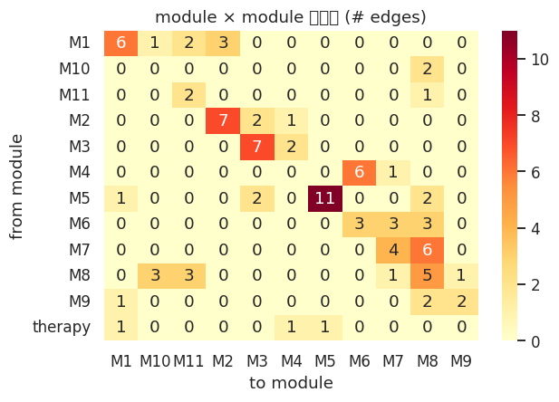

```python
# 有多少条边从 module A 跳到 module B？
edge_density = pd.crosstab(edges["module_from"], edges["module_to"])
fig, ax = plt.subplots(figsize=(6, 4.2))
sns.heatmap(edge_density, annot=True, fmt="d", cmap="YlOrRd", ax=ax, cbar=True)
ax.set_title("module × module 边密度 (# edges)")
ax.set_xlabel("to module")
ax.set_ylabel("from module")
plt.tight_layout(); plt.show()
```

### (d) 分布

- **Geographics**（图上的"地理"= 节点所在 module + host/therapy 侧）
- **整体分布**：所有 node type、edge relation

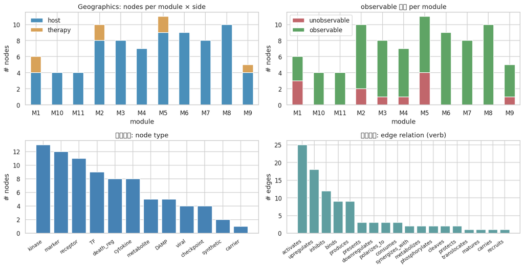

```python
fig, axes = plt.subplots(2, 2, figsize=(13.5, 7))

# (d.1) Geographics: module × side
ms = pd.crosstab(nodes["module"], nodes["side"])
ms.plot(kind="bar", stacked=True, ax=axes[0,0],
        color={"host": "#4a8fba", "therapy": "#d8a259"})
axes[0,0].set_title("Geographics: nodes per module × side")
axes[0,0].set_ylabel("# nodes")
axes[0,0].tick_params(axis="x", rotation=0)
axes[0,0].legend(title="", frameon=False)

# (d.2) Geographics: observable vs not, by module
mo = pd.crosstab(nodes["module"], nodes["observable"])
mo.columns = [{True:"observable", False:"unobservable"}.get(c, c) for c in mo.columns]
mo.plot(kind="bar", stacked=True, ax=axes[0,1],
        color={"observable": "#5fa465", "unobservable": "#c1666b"})
axes[0,1].set_title("observable 节点 per module")
axes[0,1].set_ylabel("# nodes")
axes[0,1].tick_params(axis="x", rotation=0)

# (d.3) 整体分布: node type
vc = nodes["type"].value_counts()
axes[1,0].bar(range(len(vc)), vc.values, color="steelblue")
axes[1,0].set_xticks(range(len(vc)))
axes[1,0].set_xticklabels(vc.index, rotation=35, ha="right", fontsize=9)
axes[1,0].set_title("整体分布: node type")
axes[1,0].set_ylabel("# nodes")

# (d.4) 整体分布: edge relation
vc = edges["relation"].value_counts()
axes[1,1].bar(range(len(vc)), vc.values, color="cadetblue")
axes[1,1].set_xticks(range(len(vc)))
axes[1,1].set_xticklabels(vc.index, rotation=35, ha="right", fontsize=9)
axes[1,1].set_title("整体分布: edge relation (verb)")
axes[1,1].set_ylabel("# edges")

plt.tight_layout(); plt.show()
```

# §2 · 数据处理阶段

原始数据不能直接进模型。要经过四步处理才能得到最终训练表：

1. **§2.1.1** 表达矩阵 → 通路节点对齐（20,530 基因 → 70 个 observable 节点）
2. **§2.1.2** 从 6 基因签名构造代理 label
3. **§2.1.3** 合并 pathway-aligned expression + 临床关键字段 + 生存终点 + label
4. **§2.1.4** 合并后的最终训练表 · shape · head · 复现 Fig.1C 验证

## §2.1 · 合并后的数据库信息

```python
# Aggregate symbols 的候选展开规则（和 bovin_demo.data.gene_mapping 一致）
def candidate_symbols(sym: str) -> list[str]:
    cleaned = sym.replace("|", "/").strip()
    parts = [p.strip() for p in cleaned.split("/") if p.strip()]
    return parts or [sym]

def align_expression_to_nodes(expr: pd.DataFrame, nodes_df: pd.DataFrame):
    observable = nodes_df[nodes_df["observable"]]
    aligned = {}
    hits, misses, aggregates = [], [], {}
    gset = set(expr.columns)
    for _, node in observable.iterrows():
        cands = candidate_symbols(node["symbol"])
        present = [s for s in cands if s in gset]
        if not present:
            misses.append(node["id"])
            aligned[node["id"]] = pd.Series(np.nan, index=expr.index, dtype="float64")
            continue
        if len(present) == 1:
            s = expr[present[0]].astype("float64")
        else:
            s = expr.loc[:, present].mean(axis=1)
        if len(cands) > 1:
            aggregates[node["id"]] = present
        aligned[node["id"]] = s.rename(node["id"]).astype("float64")
        hits.append(node["id"])
    out = pd.DataFrame(aligned, index=expr.index)
    return out, {"hit_rate": len(hits)/len(observable), "n_observable": len(observable),
                 "n_hits": len(hits), "n_misses": len(misses),
                 "misses": misses, "aggregates": aggregates}

path_coad, rpt_coad = align_expression_to_nodes(expr_c, nodes)
path_luad, rpt_luad = align_expression_to_nodes(expr_l, nodes)
print(f"COAD: {expr_c.shape[1]:,} genes → {path_coad.shape[1]} pathway-aligned features")
print(f"      hit_rate = {rpt_coad['hit_rate']:.3f}  ({rpt_coad['n_hits']}/{rpt_coad['n_observable']})")
print(f"LUAD: {expr_l.shape[1]:,} genes → {path_luad.shape[1]} pathway-aligned features")
print(f"      hit_rate = {rpt_luad['hit_rate']:.3f}  ({rpt_luad['n_hits']}/{rpt_luad['n_observable']})")
print(f"      misses = {rpt_coad['misses']}")
```

```
COAD: 20,530 genes → 70 pathway-aligned features
      hit_rate = 0.957  (67/70)
LUAD: 20,530 genes → 70 pathway-aligned features
      hit_rate = 0.957  (67/70)
      misses = ['type1_ifn', 'trg_d', 'adgre1']
```

### §2.1.2 · 代理 label 构造

```python
POS = ["CALR", "HMGB1", "HSPA1A", "HSP90AA1"]
NEG = ["CD47", "CD24"]

def zscore(s):
    sd = s.std(ddof=0)
    if sd == 0 or np.isnan(sd): return pd.Series(0.0, index=s.index)
    return (s - s.mean()) / sd

def make_label(expr):
    score = pd.Series(0.0, index=expr.index)
    for g in POS:
        if g in expr.columns: score = score + zscore(expr[g])
    for g in NEG:
        if g in expr.columns: score = score - zscore(expr[g])
    label = (score > score.median()).astype(int).rename("icd_label")
    return score.rename("icd_score"), label

score_c, label_c = make_label(expr_c)
score_l, label_l = make_label(expr_l)
print(f"COAD: label positive rate = {label_c.mean():.3f}  (n={len(label_c)})")
print(f"LUAD: label positive rate = {label_l.mean():.3f}  (n={len(label_l)})")
```

```
COAD: label positive rate = 0.498  (n=329)
LUAD: label positive rate = 0.500  (n=576)
```

### §2.1.3 · 合并成最终训练表

这是 **对 BOVIN demo 最重要的一张表**。每一行 = 一个 TCGA 样本，它包含：

[output not shown]

```python
def build_merged(expr, clin, surv, pathway_aligned, score, label, cohort):
    # 只取双方都有的 sample
    common = expr.index.intersection(clin.index)
    if surv is not None:
        common = common.intersection(surv.index)
    clin_cols = [c for c in KEY_CLIN if c in clin.columns]
    surv_cols = ["OS", "OS.time", "PFI", "PFI.time"]
    surv_cols = [c for c in surv_cols if c in surv.columns]

    merged = pd.concat([
        pathway_aligned.loc[common].add_prefix("node_"),
        clin.loc[common, clin_cols],
        surv.loc[common, surv_cols],
        score.loc[common],
        label.loc[common],
    ], axis=1)
    merged["cohort"] = cohort
    return merged

merged_c = build_merged(expr_c, clin_c, surv_c, path_coad, score_c, label_c, "COAD")
merged_l = build_merged(expr_l, clin_l, surv_l, path_luad, score_l, label_l, "LUAD")
print(f"COAD merged shape: {merged_c.shape}")
print(f"LUAD merged shape: {merged_l.shape}")
```

```
COAD merged shape: (326, 84)
LUAD merged shape: (576, 82)
```